# Final

Yiping Li 2022-12-08

```r
library(readxl)
library(plyr)
library(dplyr)
library(skimr)
library(ggplot2)
```

Introduction: In the United States, more than half of the total dietary energy consumption has been composed by ultra-processed foods (UPFs). Most UPFs are calorie-dense and high in sugar, salt, and unhealthy fats, while low in protein, vitamins, and minerals. Studies have demonstrated that the increased consumption of UPFs could result in a poor nutritional quality of the overall diet and high chances of developing chronic diseases. Therefore, the aim of the study focuses on exploring the association between UPF consumption and obesity, which is the primary study interest, and type 2 diabetes (T2DM) among young adults, using data obtained from the Children’s Health Study (CHS).

Method: UPF Classification In this study, UPFs are defined as food items that go through multiple manipulated process before people purchase or eat them. A total of 1167 food items (including ingredients) were collected at baseline visit and a total of 807 food items were collected were collected at follow-up visit using the 24-hour dietary recalls (24HRs). Two reviewers conducted following two processes independently. Firstly, reviewers used NOVA classification to group food items into 4 groups: unprocessed and minimally processed foods, processed culinary ingredients, processed foods, and ultra-processed foods (UPFs). Secondly, reviewers grouped the first 3 groups into non-UPFs group, so only two groups were resulted. After grouping, reviewers had disagreements on food item classification, reviewers share own perspectives to seek an agreement. In general, UPF classification criteria were as following: the major ingredient of a food item; how the food is made in the U.S. normally; the way most people get the food – purchase from a grocery store or homemade.

The data used were obtained from the baseline visit (between 2014 and 2018) of the CHS, which contained 158 participants aging from 17 to 22 years old. The 24-hour dietary recall was used to obtain the food items that participants consumed and to further calculate the UPF consumption percentage (UPF%). The inclusion criteria of participants were successfully completing the 24-hour dietary recall, BMI measurement, and glucose measurements. UPF% equaled to the UPF consumption amount in grams divided by total food consumption amount in grams. Demographic variables, body mass index (BMI), UPF%, and T2DM related variables (fasting glucose, blood glucose after 120 minutes, and HbA1c) were included in this study. BMI was used as the reference of obesity, and fasting glucose and blood glucose after 120 minutes were used as references of T2DM.

```r
metaair <- readRDS("/Users/yiping/Desktop/Epi research/OneDrive - University of Southern California/MetaChem/metaair.rds")
UPFMean_grams <- read_excel("/Users/yiping/Desktop/Epi research/USC-Liz/independent research - UPF/UPF% calculation2/UPFgrams_baseline.xlsx")
```

```r
myvars <- c("ID", "cage", "male", "race2", "bmi_avg", "bmiclass", "diabetesbinary", "gluc_fasting", "gluc_120min", "hba1c")
subsetmetachem <- metaair[myvars]
```

```r
vars <- merge(subsetmetachem, UPFMean_grams)
```

To better apply the numeric variable (the UPF%) in the study, the author created 2 categorical UPF% variables. The first one has 4 groups, which was created by evenly dividing the UPF% into 4 groups. The second one was a binary UPF variable, which was created by assuming those who consumed less than 50% of UPFs as low UPF consumption group and the rest as high UPF consumption group.

```r
vars$UPF_cat <- cut(vars$UPFpercentage_mean,
                          breaks=c(0, 25, 50, 75, 100),
                          labels=c("1", "2", "3", "4"))

vars$UPF_binary <- cut(vars$UPFpercentage_mean,
                             breaks=c(0, 50, 100),
                             labels=c("0", "1"))
```

Appropriate names of variables were given to better view the dataset.

```r
names(vars)[2] <- "Age"
names(vars)[3] <- "Male"
names(vars)[4] <- "Race"
names(vars)[5] <- "BMI_cont"
names(vars)[6] <- "BMI_cat"
names(vars)[7] <-  "Diabetes_cat"
names(vars)[8] <- "Gluc_Fasting"
names(vars)[9] <- "Gluc_120min"
names(vars)[10] <- "HbA1C"
```

To better use the numeric variable, sex, I changed the format of it into a categorical variable to give proper names of the groups in it.

```r
vars$Male <- as.factor(vars$Male)
vars$Male <- revalue(vars$Male, c("0" = "Female", "1" = "Male"))
```

Participants with missing values in T2DM or fasting glucose or blood glucose after 120 minutes were excluded. Participants with implausible fasting glucose of greater than 200 mg/dL and blood glucose after 120 minutes of greater than 400 mg/dL were also excluded.

```r
vars <- vars %>%
  filter(!is.na(Diabetes_cat)) %>%
  filter(!is.na(Gluc_Fasting)) %>%
  filter(!is.na(Gluc_120min)) %>%
  filter(Gluc_Fasting < 200) %>%
  filter(Gluc_120min < 400)
```

A new categorical variable (names as “UPF and BMI”), that contained all cases of the UPF binary variable and 3 BMI categories combination was created to explore the association between UPF consumption and BMI.

```r
vars <- vars %>%
  mutate(UPF_BMI = factor(
    case_when(UPF_binary == 0 & BMI_cat == "Normal" ~ "Low UPF Normal Weight",
              UPF_binary == 0 & BMI_cat == "Overweight" ~ "Low UPF Overweight",
              UPF_binary == 0 & BMI_cat == "Obese" ~ "Low UPF Obese",
              UPF_binary == 1 & BMI_cat == "Normal" ~ "High UPF Normal Weight",
              UPF_binary == 1 & BMI_cat == "Overweight" ~ "High UPF Overweight",
              UPF_binary == 1 & BMI_cat == "Obese" ~ "High UPF Obese")
  ))

vars<- vars %>%
  filter(!is.na(UPF_BMI))
```

Tables were created for readers to understand the numeric values of study of interests. Summaries tables of fasting glucose and blood glucose after 120 minutes containing total numbers, minimum values, and maximum values in regard to UPF 4 groups, UPF binary variable, and BMI categories were created. The summary table of number of subjects for each “UPF and BMI” combination was also created.

Table 1 to 3 are descriptive tables showing the number of participants, the minimum and maximum vales of fasting glucose and blood glucose after 120 minutes. Most participants were overweight obese and ate less than 50% of UPFs. Only 4 participants ate UPF in 50-75% and only 1 participant ate UPF greater than 75%.

```r
table1 <- vars %>%
  group_by(BMI_cat) %>%
  summarise(
    Gluc_Fasting_min = min(Gluc_Fasting),
    Gluc_Fasting_max = max(Gluc_Fasting),
    Gluc_120min_min = min(Gluc_120min),
    GLuc_120min_max = max(Gluc_120min),
    Gluc_num = n(),
  )
knitr::kable(table1)
```

| BMI_cat | Gluc_Fasting_min | Gluc_Fasting_max | Gluc_120min_min | GLuc_120min_max | Gluc_num |
| --- | --- | --- | --- | --- | --- |
| Normal | 74 | 107 | 55 | 176 | 24 |
| Obese | 77 | 119 | 83 | 208 | 56 |
| Overweight | 76 | 107 | 55 | 200 | 73 |

```r
table2 <- vars %>%
  group_by(UPF_cat) %>%
  summarise(
    Gluc_Fasting_min = min(Gluc_Fasting),
    Gluc_Fasting_max = max(Gluc_Fasting),
    Gluc_120min_min = min(Gluc_120min),
    Gluc_120min_max = max(Gluc_120min),
    Gluc_num = n(),
  )
knitr::kable(table2)
```

| UPF_cat | Gluc_Fasting_min | Gluc_Fasting_max | Gluc_120min_min | Gluc_120min_max | Gluc_num |
| --- | --- | --- | --- | --- | --- |
| 1 | 76 | 119 | 55 | 208 | 105 |
| 2 | 74 | 110 | 70 | 200 | 43 |
| 3 | 76 | 95 | 99 | 131 | 4 |
| 4 | 91 | 91 | 135 | 135 | 1 |

```r
table3 <- vars %>%
  group_by(UPF_binary) %>%
  summarise(
    Gluc_Fasting_min = min(Gluc_Fasting),
    Gluc_Fasting_max = max(Gluc_Fasting),
    Gluc_120min_min = min(Gluc_120min),
    GLuc_120min_max = max(Gluc_120min),
    Gluc_num = n(),
  )
knitr::kable(table3)
```

| UPF_binary | Gluc_Fasting_min | Gluc_Fasting_max | Gluc_120min_min | GLuc_120min_max | Gluc_num |
| --- | --- | --- | --- | --- | --- |
| 0 | 74 | 119 | 55 | 208 | 148 |
| 1 | 76 | 95 | 99 | 135 | 5 |

Table 4 combines the circumstances of UPF consumption and BMI categories, indicating that most participants ate low UPF in their diet and were overweight or obese.

```r
table4 <- vars %>%
  group_by(UPF_BMI) %>%
  summarise(
    Group_num = n(),
  )
knitr::kable(table4)
```

| UPF_BMI | Group_num |
| --- | --- |
| High UPF Obese | 2 |
| High UPF Overweight | 3 |
| Low UPF Normal Weight | 24 |
| Low UPF Obese | 54 |
| Low UPF Overweight | 70 |

Figure 1 to 3 shows UPF% vs BMI, fasting glucose, and blood glucose after 120 minutes correspondingly. No clear patten between UPF% and those variables interested in is seen from those figures.

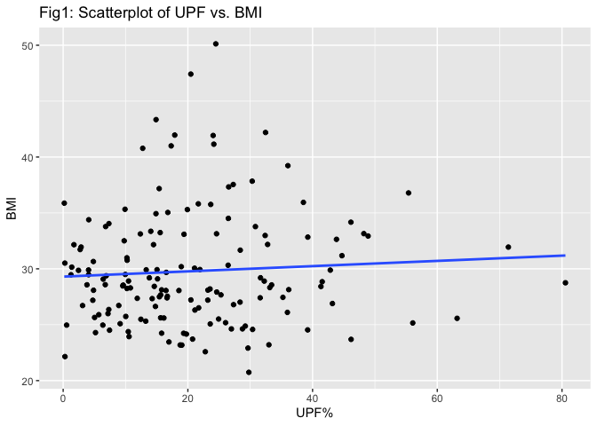

```r
ggplot(vars, aes(x = UPFpercentage_mean, y = BMI_cont)) +
  geom_point() +
  labs(title = "Fig1: Scatterplot of UPF vs. BMI", x = "UPF%", y = "BMI") +
  geom_smooth(method = lm, se = FALSE)
```

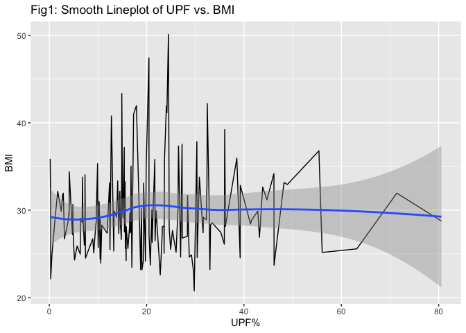

```r
ggplot(vars, aes(x = UPFpercentage_mean, y = BMI_cont)) +
  geom_line () +
  geom_smooth () +
  labs(title = "Fig1: Smooth Lineplot of UPF vs. BMI", x = "UPF%", y = "BMI")
```

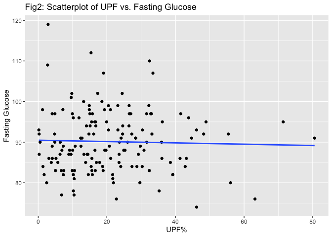

```r
ggplot(vars, aes(x = UPFpercentage_mean, y = Gluc_Fasting)) +
  geom_point() +
  labs(title = "Fig2: Scatterplot of UPF vs. Fasting Glucose", x = "UPF%", y = "Fasting Glucose") +
  geom_smooth(method = lm, se = FALSE)
```

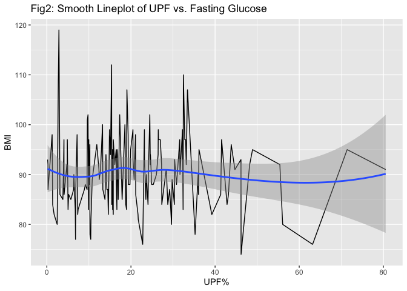

```r
ggplot(vars, aes(x = UPFpercentage_mean, y = Gluc_Fasting)) +
  geom_line () +
  geom_smooth () +
  labs(title = "Fig2: Smooth Lineplot of UPF vs. Fasting Glucose", x = "UPF%", y = "BMI")
```

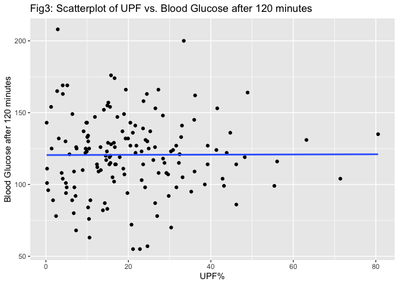

```r
ggplot(vars, aes(x = UPFpercentage_mean, y = Gluc_120min)) +
  geom_point() +
  labs(title = "Fig3: Scatterplot of UPF vs. Blood Glucose after 120 minutes", x = "UPF%", y = "Blood Glucose after 120 minutes") +
  geom_smooth(method = lm, se = FALSE)
```

[figure not shown]

```r
ggplot(vars, aes(x = UPFpercentage_mean, y = Gluc_Fasting)) +
  geom_line () +
  geom_smooth () +
  labs(title = "Fig3: Smooth Lineplot of UPF vs. Blood Glucose after 120 minutes", x = "UPF%", y = "Blood Glucose after 120 minutes")
```

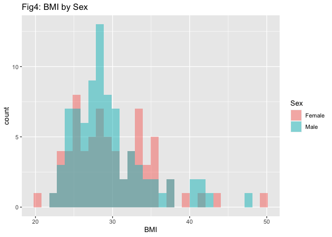

```r
vars %>%
  ggplot(aes(x = BMI_cont, fill = as.factor(Male))) +
  geom_histogram(position = "identity", alpha = 0.5) +
  labs(title = "Fig4: BMI by Sex", x = "BMI", fill = "Sex")
```

Figure 5, UPF% by sex, shows that both males and females have right skewed bell shapes, and males have high UPF%. Figure 6, UPF% by BMI, straightly shows that more participants were overweight and consumed less than 40% UPFs.

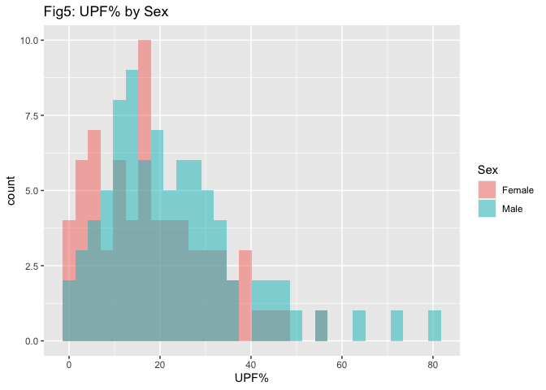

```r
vars %>%
  ggplot(aes(x = UPFpercentage_mean, fill = Male)) +
  geom_histogram(position = "identity", alpha = 0.5) +
  labs(title = "Fig5: UPF% by Sex", x = "UPF%", fill = "Sex")
```

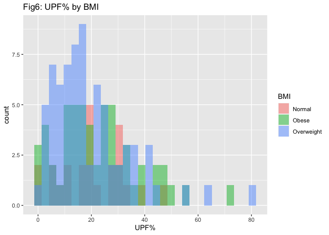

```r
vars %>%
  ggplot(aes(x = UPFpercentage_mean, fill = BMI_cat)) +
  geom_histogram(position = "identity", alpha = 0.5) +
  labs(title = "Fig6: UPF% by BMI", x = "UPF%", fill = "BMI")
```

Figure 7 shows Table 4 in a visualized way, but it does not indicate any association between UPF plus BMI and UPF 4 categories.

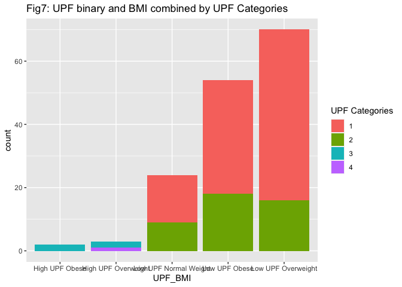

```r
vars %>%
  ggplot(aes(x = UPF_BMI, fill = UPF_cat)) +
  geom_bar() +
  labs(title = "Fig7: UPF binary and BMI combined by UPF Categories", x = "UPF_BMI", fill = "UPF Categories")
```

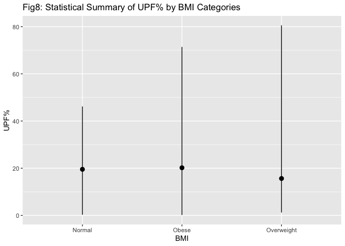

```r
vars %>%
  ggplot() +
  stat_summary(mapping = aes(x = BMI_cat, y = UPFpercentage_mean),
               fun.min = min,
               fun.max = max,
               fun = median) +
  labs(title = "Fig8: Statistical Summary of UPF% by BMI Categories", x = "BMI", y = "UPF%")
```

Conclusion: Based on the above data exploration and graphs, no clear pattern shows that UPF consumption is associated with obesity or T2DM, indicating by BMI categories and blood glucose. One reason can be the number of participants is limited. The other reason might be limited outcomes of interests to study. Only 3 variables were used to make tables and figures to visualize. Although this study does not any association between UPF consumption and obesity and T2DM, further studies are needed to explore any potential relationships between UPFs and metabolic diseases.